# Predictive Analytics in Formula 1: Qualifying Performance and Race Outcomes

##### by Vikranth Reddimasu

1. Introduction & Objective
2. Part 1: Data Preparation
   - Data Overview
3. Part 2: Exploratory Data Analysis
   - Interactive Driver Data Filter
   - Exploratory Visualizations
     - Visualization 1: Distribution of Driver Nationalities
     - Visualization 2: Top 10 Drivers by Race Wins
     - Visualization 3: Number of Races Hosted by Each Circuit
     - Visualization 4: Top Constructors by Championships Won
     - Visualization 5: Performance Trends of Top Constructors
     - Visualization 6: Distribution of Driver Career Lengths
     - Visualization 7: Driver Career Lengths by Nationality
     - Visualization 8: Aggregating Constructor Performance Based on Points
     - Feature Correlation Heatmap
   - Statistical Analysis 1
   - Statistical Analysis 2
4. Part 3: Predictive Modeling & Machine Learning Models
   - Objective 1: Predict Race Winners
     - Random Forest without Tuning
     - Logistic Regression with feature scaling
     - Model Tuning for Logistic Regression and Random Forest
     - Classification Model Performance Comparison
   - Objective 2: Predicting Qualifying Positions
     - Random Forest Regressor for Predicting Qualifying Positions
     - Optimized Random Forest Regressor with Grid Search
     - Regression Model Performance Comparison
5. Summary
6. References and Resources

## Introduction

Formula 1 racing is a pinnacle of motorsport, combining cutting-edge engineering with human skill and strategy. This project explores historical Formula 1 datasets to analyze trends, uncover insights, and develop predictive models. By leveraging advanced data science techniques, we aim to enhance our understanding of the factors influencing race outcomes and qualifying performance.

### Objectives:

1. Analyze historical trends in Formula 1 data (drivers, constructors, circuits).
2. The project is divided into two primary objectives:
   - Predicting race wins.
   - Predicting qualifying positions.
3. Derive actionable insights from data analysis and modeling.

## Part 1 - Data Preparation

### Data Overview

This project uses historical Formula 1 data spanning several decades, including datasets on drivers, constructors, circuits, races, results, and more.

#### Key Datasets:

1. **Drivers**: Information about drivers, including nationality and date of birth.
2. **Constructors**: Data about constructor teams and their nationalities.
3. **Races**: Details about each race, including the year, circuit, and race ID.
4. **Results**: Race results, including finishing positions and points.
5. **Qualifying**: Qualifying session data, including positions and lap times.

#### Data Cleaning and Preparation:

1. Handled missing values and inconsistent formats.
2. Engineered features:
   - **Driver career length**: Years between a driver's first and last race.
   - **Constructor total points**: Aggregated points earned by constructors.
   - **Nationality Encoding**: Converted categorical nationalities into numeric codes.

### Dataset Loading and Initial Exploration

This section loads all relevant datasets for the project and performs initial exploration to understand their structure. The following steps are taken:

1. Load all datasets from the provided file paths into a dictionary for easy access.
2. Display the shape of each dataset during loading to verify data integrity.
3. Perform basic data cleaning, such as:
   - Converting the `drivers['number']` column to numeric format.
   - Converting `constructors['nationality']` to a categorical data type.
4. Display column information for the `results` dataset as an example to check data types and missing values.

```python
import pandas as pd

# Define a function to load data and print information
def load_data(file_path):
    data = pd.read_csv(file_path)
    print(f"Loaded {file_path.split('/')[-1]} with shape {data.shape}")
    return data

# Paths to the dataset files
dataset_paths = {
    "circuits": "/Users/vikranthreddimasu/Downloads/DS/Datasets/circuits.csv",
    "constructor_results": "/Users/vikranthreddimasu/Downloads/DS/Datasets/constructor_results.csv",
    "constructor_standings": "/Users/vikranthreddimasu/Downloads/DS/Datasets/constructor_standings.csv",
    "constructors": "/Users/vikranthreddimasu/Downloads/DS/Datasets/constructors.csv",
    "driver_standings": "/Users/vikranthreddimasu/Downloads/DS/Datasets/driver_standings.csv",
    "drivers": "/Users/vikranthreddimasu/Downloads/DS/Datasets/drivers.csv",
    "lap_times": "/Users/vikranthreddimasu/Downloads/DS/Datasets/lap_times.csv",
    "pit_stops": "/Users/vikranthreddimasu/Downloads/DS/Datasets/pit_stops.csv",
    "qualifying": "/Users/vikranthreddimasu/Downloads/DS/Datasets/qualifying.csv",
    "races": "/Users/vikranthreddimasu/Downloads/DS/Datasets/races.csv",
    "results": "/Users/vikranthreddimasu/Downloads/DS/Datasets/results.csv",
    "seasons": "/Users/vikranthreddimasu/Downloads/DS/Datasets/seasons.csv",
    "sprint_results": "/Users/vikranthreddimasu/Downloads/DS/Datasets/sprint_results.csv",
    "status": "/Users/vikranthreddimasu/Downloads/DS/Datasets/status.csv"
}

# Load all datasets
datasets = {name: load_data(path) for name, path in dataset_paths.items()}

# Example of basic data cleaning on a selected dataset
datasets['drivers']['number'] = pd.to_numeric(datasets['drivers']['number'], errors='coerce')
datasets['constructors']['nationality'] = datasets['constructors']['nationality'].astype('category')

# Print information for one of the datasets to check data types and missing values
print(datasets['results'].info())
```

```
The history saving thread hit an unexpected error (OperationalError('attempt to write a readonly database')).History will not be written to the database.
Loaded circuits.csv with shape (77, 9)
Loaded constructor_results.csv with shape (12505, 5)
Loaded constructor_standings.csv with shape (13271, 7)
Loaded constructors.csv with shape (212, 5)
Loaded driver_standings.csv with shape (34595, 7)
Loaded drivers.csv with shape (859, 9)
Loaded lap_times.csv with shape (575029, 6)
Loaded pit_stops.csv with shape (10990, 7)
Loaded qualifying.csv with shape (10254, 9)
Loaded races.csv with shape (1125, 18)
Loaded results.csv with shape (26519, 18)
Loaded seasons.csv with shape (75, 2)
Loaded sprint_results.csv with shape (300, 16)
Loaded status.csv with shape (139, 2)
<class 'pandas.core.frame.DataFrame'>
RangeIndex: 26519 entries, 0 to 26518
Data columns (total 18 columns):
 #   Column           Non-Null Count  Dtype
---  ------           --------------  -----
 0   resultId         26519 non-null  int64
 1   raceId           26519 non-null  int64
 2   driverId         26519 non-null  int64
 3   constructorId    26519 non-null  int64
 4   number           26519 non-null  object
 5   grid             26519 non-null  int64
 6   position         26519 non-null  object
 7   positionText     26519 non-null  object
 8   positionOrder    26519 non-null  int64
 9   points           26519 non-null  float64
 10  laps             26519 non-null  int64
 11  time             26519 non-null  object
 12  milliseconds     26519 non-null  object
 13  fastestLap       26519 non-null  object
 14  rank             26519 non-null  object
 15  fastestLapTime   26519 non-null  object
 16  fastestLapSpeed  26519 non-null  object
 17  statusId         26519 non-null  int64
dtypes: float64(1), int64(8), object(9)
memory usage: 3.6+ MB
None
```

#### Summary of Dataset Loading

- All datasets were successfully loaded, with the following key observations:
  - The `drivers` dataset includes driver-specific information, such as their numbers and dates of birth.
  - The `constructors` dataset contains team-related details, including nationality.
  - The `results` dataset provides race-level information, including positions and points.
- Initial data cleaning ensures that numeric and categorical values are properly formatted for further analysis.
- No errors or significant data integrity issues were observed during the loading process.

## Part 2: Exploratory Data Analysis

#### Description:

Exploratory Data Analysis (EDA) is a fundamental step in the data science process as it allows us to open the black box of the datasets and get a sense of the story the data is telling us. In this section, we will visualize various aspects of the Formula 1 datasets, such as driver performances, constructor achievements, and race characteristics, to uncover underlying patterns and trends that have shaped the sport over the decades.

### Interactive Driver Data Filter

In this section, we leverage ipywidgets to create an interactive dropdown widget that allows users to explore the results data for a specific driver. By selecting a driver's surname from the dropdown, the corresponding race results for that driver are displayed dynamically.

This interactivity adds a layer of usability to our analysis, enabling easy exploration of driver-specific data without manually searching through large datasets.

```python
import ipywidgets as widgets
from IPython.display import display
import pandas as pd

# Ensure datasets are available and mapped
drivers['driverId'] = drivers['driverId'].astype(int)
results['driverId'] = results['driverId'].astype(int)

# Create a mapping of driver surnames to driverIds
driver_mapping = drivers[['driverId', 'surname']].set_index('surname').to_dict()['driverId']

# Dropdown for driver selection
driver_dropdown = widgets.Dropdown(
    options=drivers['surname'].unique(),  # Display surnames in the dropdown
    description='Driver:',
)

# Function to filter and display results
def filter_by_driver(driver):
    driver_id = driver_mapping[driver]  # Get the corresponding driverId
    filtered_data = results[results['driverId'] == driver_id]
    if not filtered_data.empty:
        display(filtered_data.head())
    else:
        print(f"No data available for driver: {driver}")

# Interactive widget
widgets.interactive(filter_by_driver, driver=driver_dropdown)
```

```
interactive(children=(Dropdown(description='Driver:', options=('Hamilton', 'Heidfeld', 'Rosberg', 'Alonso', 'K…
```

### Exploratory Visualizations

These visualizations aim to explore key trends and patterns in Formula 1 data related to driver nationalities and their race performances.

### Visualization 1: Distribution of Driver Nationalities

This visualization groups nationalities with fewer drivers under "Others" to simplify analysis and highlight the most represented nations in Formula 1 history.

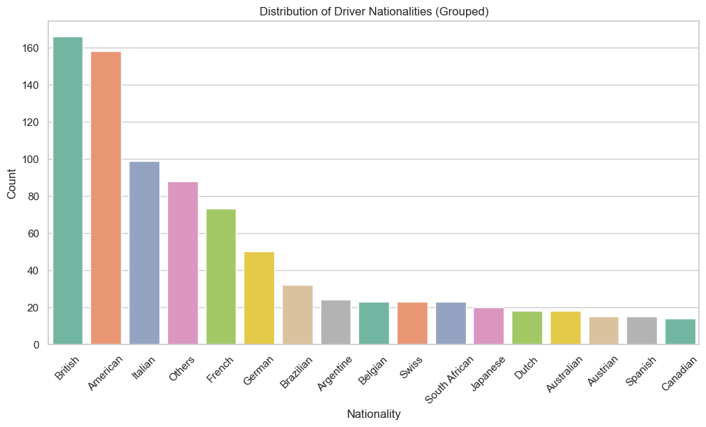

```python
import matplotlib.pyplot as plt
import seaborn as sns

# Setting aesthetic style for better visuals
sns.set(style="whitegrid")

# Load the dataset for analysis
drivers = datasets['drivers']
results = datasets['results']

# Improved Visualization 1: Distribution of Driver Nationalities (Grouped)
# Grouping smaller nationalities under 'Others' for better visualization
nationality_counts = drivers['nationality'].value_counts()
drivers['nationality_grouped'] = drivers['nationality'].apply(
    lambda x: x if nationality_counts[x] > 10 else 'Others'
)

plt.figure(figsize=(12, 6))
sns.countplot(
    x='nationality_grouped',
    data=drivers,
    palette='Set2',
    order=drivers['nationality_grouped'].value_counts().index
)
plt.title('Distribution of Driver Nationalities (Grouped)')
plt.xlabel('Nationality')
plt.ylabel('Count')
plt.xticks(rotation=45)
plt.show()
```

The above chart categorizes driver nationalities, focusing on countries with significant representation in Formula 1. Nationalities with fewer than 10 drivers are grouped under "Others" for better clarity.

### Visualization 2: Top 10 Drivers by Race Wins

The bar chart showcases the drivers with the highest number of wins, emphasizing their dominance and contribution to the sport.

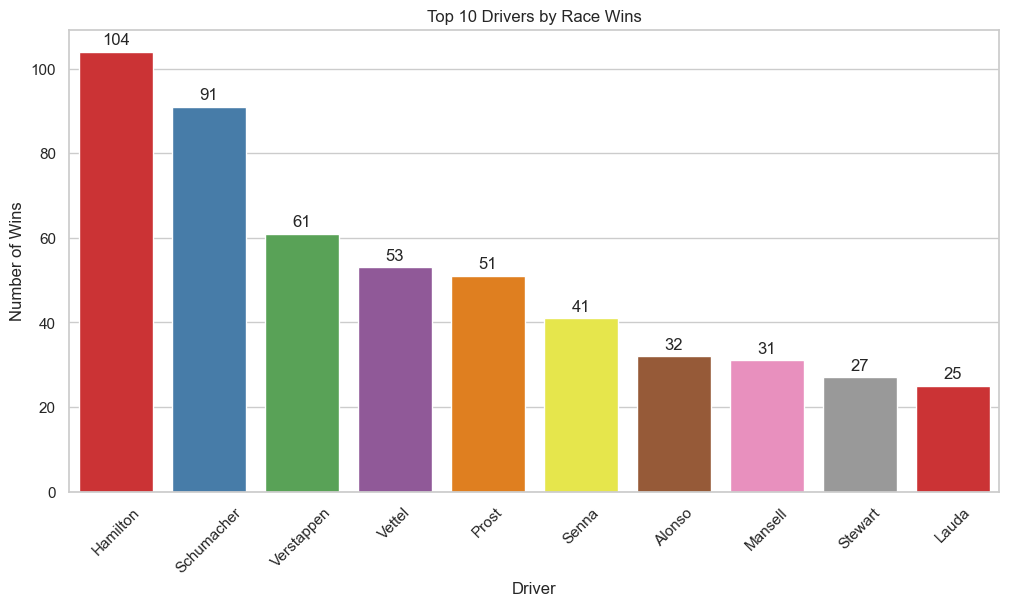

```python
# Visualization 2: Top 10 Drivers by Race Wins
# Identifying the top 10 drivers with the most race wins
top_drivers = results[results['positionOrder'] == 1]['driverId'].value_counts().head(10)
top_driver_ids = top_drivers.index
top_driver_names = drivers.set_index('driverId').loc[top_driver_ids]['surname'].values

plt.figure(figsize=(12, 6))
sns.barplot(
    x=top_driver_names,
    y=top_drivers.values,
    palette='Set1'
)
plt.title('Top 10 Drivers by Race Wins')
plt.xlabel('Driver')
plt.ylabel('Number of Wins')
plt.xticks(rotation=45)

# Adding annotations for better clarity
for i, v in enumerate(top_drivers.values):
    plt.text(i, v + 1, str(v), ha='center', va='bottom')
plt.show()
```

The above bar chart highlights the top 10 drivers with the most race wins, showcasing their dominance in Formula 1 history. Each bar is annotated with the exact number of wins for better understanding.

### Visualization 3: Number of Races Hosted by Each Circuit

Highlights the circuits that have hosted the most races, offering insights into their prominence in Formula 1 history.

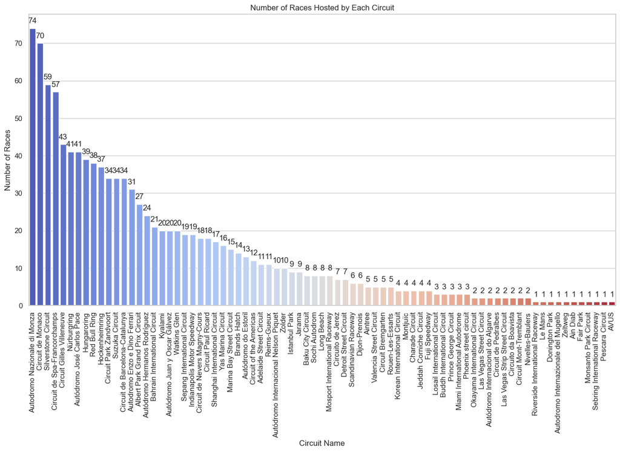

```python
# import matplotlib.pyplot as plt
import seaborn as sns

# Load additional datasets
circuits = datasets['circuits']
constructors = datasets['constructors']
races = datasets['races']
constructor_standings = datasets['constructor_standings']

# Visualization 3: Number of Races Hosted by Each Circuit
# Count races for each circuit
race_counts = races['circuitId'].value_counts().reset_index()
race_counts.columns = ['circuitId', 'num_races']

# Merge circuit names for better readability
circuit_names = race_counts.merge(circuits[['circuitId', 'name']], on='circuitId', how='left')

# Plot: Circuits ordered by number of races
plt.figure(figsize=(16, 8))
sns.barplot(
    x='name',
    y='num_races',
    data=circuit_names.sort_values(by='num_races', ascending=False),
    palette='coolwarm'
)
plt.title('Number of Races Hosted by Each Circuit')
plt.xlabel('Circuit Name')
plt.ylabel('Number of Races')
plt.xticks(rotation=90)
for i, v in enumerate(circuit_names.sort_values(by='num_races', ascending=False)['num_races']):
    plt.text(i, v + 1, str(v), ha='center', va='bottom')
plt.show()
```

- Circuits like *Autodromo Nazionale di Monza* and *Circuit de Monaco* stand out as the most frequently used tracks.
- Provides historical significance of these tracks to Formula 1.

### Visualization 4: Top Constructors by Championships Won

Identifies the constructors with the highest number of championships, showcasing dominant teams.

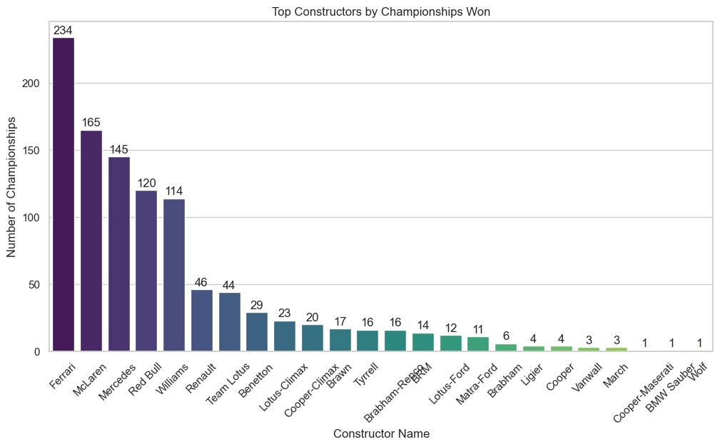

```python
# Visualization 4: Top Constructors by Championships Won
# Filter constructors with championships (position = 1)
constructor_champs = constructor_standings[constructor_standings['position'] == 1]

# Count championships for each constructor
top_constructors = constructor_champs['constructorId'].value_counts().reset_index()
top_constructors.columns = ['constructorId', 'num_championships']

# Merge constructor names
constructor_names = top_constructors.merge(constructors[['constructorId', 'name']], on='constructorId', how='left')

# Plot: Constructors ordered by championships
plt.figure(figsize=(12, 6))
sns.barplot(
    x='name',
    y='num_championships',
    data=constructor_names.sort_values(by='num_championships', ascending=False),
    palette='viridis'
)
plt.title('Top Constructors by Championships Won')
plt.xlabel('Constructor Name')
plt.ylabel('Number of Championships')
plt.xticks(rotation=45)
for i, v in enumerate(constructor_names.sort_values(by='num_championships', ascending=False)['num_championships']):
    plt.text(i, v + 1, str(v), ha='center', va='bottom')
plt.show()
```

- Teams like *Ferrari*, *McLaren*, and *Mercedes* dominate the chart with the highest number of championships.
- Demonstrates the consistency and performance of these constructors over time.

### Visualization 5: Performance Trends of Top Constructors

**Context:** Formula 1 constructors have displayed varying performances throughout the years. This visualization examines the trends in championship positions of the top constructors, focusing on those frequently appearing in the top 5.

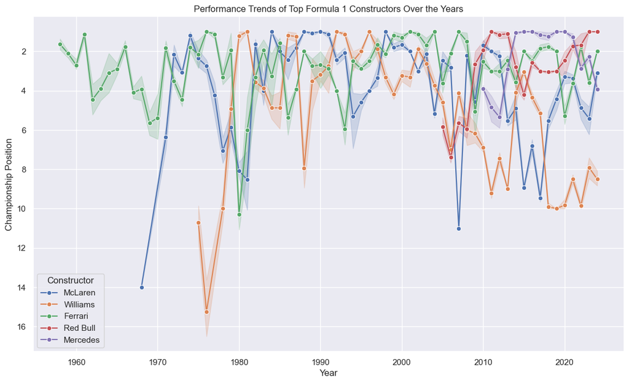

```python
import matplotlib.pyplot as plt
import seaborn as sns
import pandas as pd

# Setting the visual style
sns.set(style="darkgrid")

# Loading necessary datasets
constructor_standings = datasets['constructor_standings']
races = datasets['races']
constructors = datasets['constructors']

# Merge constructor standings with races to get year information
constructor_standings = constructor_standings.merge(races[['raceId', 'year']], on='raceId')

# Selecting top constructors based on the number of appearances in the top 5
top_constructors_ids = constructor_standings[constructor_standings['position'] <= 5]['constructorId'].value_counts().head(5).index
top_constructor_standings = constructor_standings[constructor_standings['constructorId'].isin(top_constructors_ids)]

# Merge with constructors to get the names
top_constructor_standings = top_constructor_standings.merge(constructors[['constructorId', 'name']], on='constructorId')

# Creating a line plot to show the trend of top constructors over the years
plt.figure(figsize=(14, 8))
sns.lineplot(data=top_constructor_standings, x='year', y='position', hue='name', marker='o')
plt.title('Performance Trends of Top Formula 1 Constructors Over the Years')
plt.xlabel('Year')
plt.ylabel('Championship Position')
plt.gca().invert_yaxis()  # Invert y-axis to show the best position (1) at the top
plt.legend(title='Constructor')
plt.show()
```

**Interpretation of the above Visualization:**

- The visualization highlights the consistency and dominance of constructors such as *Ferrari*, *McLaren*, and *Mercedes*.
- Peaks and troughs in performance can be observed, providing insights into periods of dominance and decline for each constructor.
- Ferrari has shown consistent top finishes, underscoring its legacy in Formula 1.
- Recent years reveal the rise of teams like *Red Bull*, showcasing their competitive edge.

This analysis helps understand how constructor strategies, technological advancements, and team dynamics influence championship standings over time.

### Visualization 6: Distribution of Driver Career Lengths

In this section, we analyze the distribution of career lengths for Formula 1 drivers. Career length is calculated as the difference between a driver's first and last year of participation. The aim is to understand the overall trend in driver career durations and identify key statistical characteristics such as mean and median career lengths.

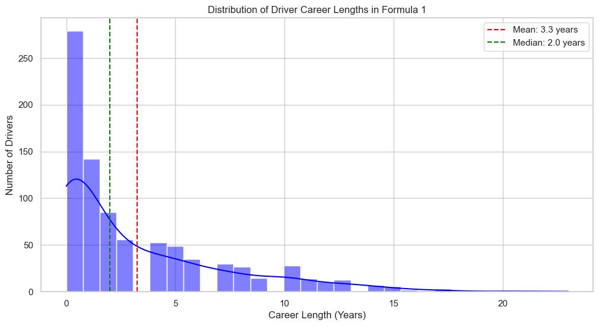

```python
import pandas as pd
import matplotlib.pyplot as plt
import seaborn as sns

# Load drivers and results datasets
drivers = datasets['drivers']
results = datasets['results']
races = datasets['races']

# Merge drivers with results to get each driver's race entries
driver_results = pd.merge(drivers, results, on='driverId')

# Merge with races to get the year of each race
driver_results = pd.merge(driver_results, races[['raceId', 'year']], on='raceId')

# Group by driver and get the first and last year of participation
career_lengths = driver_results.groupby('driverId').agg(first_year=('year', 'min'), last_year=('year', 'max'))
career_lengths['career_length'] = career_lengths['last_year'] - career_lengths['first_year']

# Visualization of career lengths
plt.figure(figsize=(12, 6))
sns.histplot(career_lengths['career_length'], bins=30, kde=True, color='blue')
plt.title('Distribution of Driver Career Lengths in Formula 1')
plt.axvline(career_lengths['career_length'].mean(), color='red', linestyle='--', label=f'Mean: {career_lengths["career_length"].mean():.1f} years')
plt.axvline(career_lengths['career_length'].median(), color='green', linestyle='--', label=f'Median: {career_lengths["career_length"].median():.1f} years')
plt.xlabel('Career Length (Years)')
plt.ylabel('Number of Drivers')
plt.legend()
plt.show()
```

The resulting histogram displays the distribution of driver career lengths:

- Key Observations:
  - Most drivers have short careers, with the majority lasting fewer than five years.
  - The mean career length is marked by the red dashed line, while the median is marked by the green dashed line.
- Takeaway: The skewed distribution indicates that a small subset of drivers has notably long careers, but the majority of careers are relatively brief.

### Visualization 7: Driver Career Lengths by Nationality

To explore potential differences in career longevity across nationalities, this section groups drivers by their nationality and visualizes their career lengths using a boxplot. Smaller nationalities are grouped under "Others" for clarity.

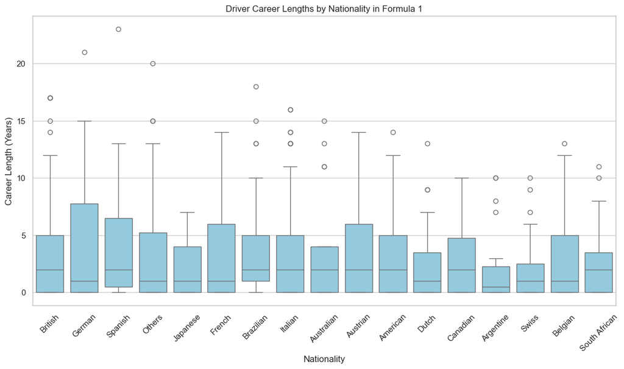

```python
# Analyze career length by nationality
career_lengths = career_lengths.merge(drivers[['driverId', 'nationality']], on='driverId')

# Grouping smaller nationalities under 'Others' for readability
nationality_counts = career_lengths['nationality'].value_counts()
career_lengths['nationality_grouped'] = career_lengths['nationality'].apply(
    lambda x: x if nationality_counts[x] > 10 else 'Others'
)

plt.figure(figsize=(14, 7))
sns.boxplot(x='nationality_grouped', y='career_length', data=career_lengths, color='skyblue')
plt.title('Driver Career Lengths by Nationality in Formula 1')
plt.xlabel('Nationality')
plt.ylabel('Career Length (Years)')
plt.xticks(rotation=45)
plt.show()
```

### Visualization 8: Aggregating Constructor Performance Based on Points

Constructors in Formula 1 play a pivotal role in shaping the performance of drivers and teams. To better understand the success of constructors over the years, we aggregate their total points across all races. This analysis provides insights into which constructors consistently excel and dominate the sport.

The dataset is preprocessed by:

- Verifying the columns in the `constructor_results` dataset.
- Merging it with the `results` dataset to include relevant fields such as `points`.
- Aggregating the total points earned by each constructor and sorting them to identify the top 10 constructors.

The goal is to create a clear visualization showcasing the constructors with the highest total points.

```
Columns in constructor_results: Index(['constructorResultsId', 'raceId', 'constructorId', 'points', 'status'], dtype='object')
Columns after merge: Index(['resultId', 'raceId', 'driverId', 'constructorId', 'number', 'grid',
       'position', 'positionText', 'positionOrder', 'points_x', 'laps', 'time',
       'milliseconds', 'fastestLap', 'rank', 'fastestLapTime',
       'fastestLapSpeed', 'statusId', 'points_y'],
      dtype='object')
Aggregation successful, here are the top constructors by points:
     constructorId  points_y         name
5                6   20472.0      Ferrari
8                9   15242.0     Red Bull
124            131   14887.0     Mercedes
0                1   13578.0      McLaren
2                3    7368.0     Williams
3                4    3551.0      Renault
9               10    2196.0  Force India
31              32    2193.0   Team Lotus
21              22    1723.0     Benetton
168            208    1412.0     Lotus F1
```

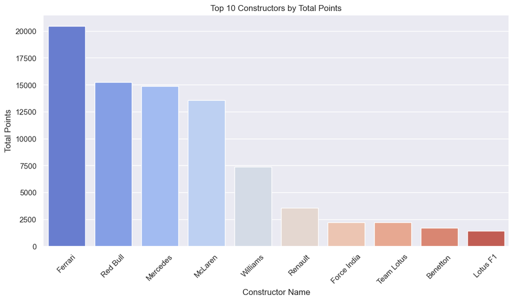

```python
import pandas as pd
import matplotlib.pyplot as plt
import seaborn as sns

# Load the dataset
constructor_results = datasets['constructor_results']

# Verify columns immediately after loading
print("Columns in constructor_results:", constructor_results.columns)

# Merge results with constructor results and directly work with points
results_constructors = pd.merge(results, constructor_results[['raceId', 'constructorId', 'points']], on=['raceId', 'constructorId'], how='inner')

# Verify columns after merge to ensure 'points' is still there
print("Columns after merge:", results_constructors.columns)

# Aggregation of points by constructor
try:
    constructor_points = results_constructors.groupby('constructorId')['points_y'].sum().reset_index()
    constructor_points = constructor_points.merge(constructors[['constructorId', 'name']], on='constructorId', how='left')
    constructor_points = constructor_points.sort_values(by='points_y', ascending=False).head(10)  # Top 10 constructors
    print("Aggregation successful, here are the top constructors by points:")
    print(constructor_points)
except KeyError as e:
    print("Error during aggregation:", e)

# Plotting the top constructors by points
plt.figure(figsize=(12, 6))
sns.barplot(x='name', y='points_y', data=constructor_points, palette='coolwarm')
plt.title('Top 10 Constructors by Total Points')
plt.xlabel('Constructor Name')
plt.ylabel('Total Points')
plt.xticks(rotation=45)
plt.show()
```

#### Insights from Constructor Performance Analysis

The results highlight the top-performing constructors in Formula 1 based on their accumulated points:

1. *Ferrari* leads the chart with the highest total points, showcasing their legacy and dominance in the sport.
2. *Red Bull* and Mercedes follow, reflecting their modern era success and competitiveness.
3. *McLaren* and *Williams*, while historically dominant, remain prominent in the overall rankings.

The bar chart clearly emphasizes the constructors' relative performance, with a significant gap between the top-ranked constructors and others. These insights not only reflect competitive dynamics but also underscore the importance of technological innovation and team strategy in Formula 1.

#### Feature Correlation Heatmap

```python
import plotly.express as px
import pandas as pd

# Compute correlations
correlation_matrix = data.corr()

# Create an interactive heatmap
fig = px.imshow(correlation_matrix,
                title="Feature Correlation Heatmap",
                labels=dict(color="Correlation"),
                color_continuous_scale="Viridis")
fig.show()
```

[interactive chart not shown]

### Statistical Analysis 1

**Purpose:** In this analysis, we aim to uncover patterns and relationships between driver wins, their career lengths, and their nationalities. By using statistical methods and visualizations, we examine:

1. Wins by Nationality: To see if driver nationalities are a factor in achieving success (number of wins).
2. Correlation Between Career Length and Wins: To analyze whether drivers with longer careers achieve more victories.

We utilize an ANOVA test to determine if there are significant differences in wins among nationalities and Pearson correlation to evaluate the relationship between career length and wins.

```
ANOVA test result for difference in wins by nationality: F-statistic = 3.44, p-value = 0.0128
```

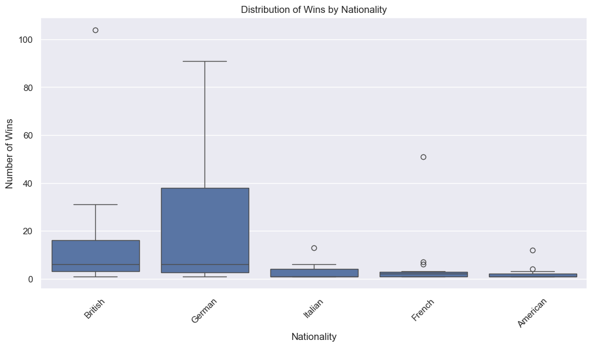

```
Correlation between career length and number of wins: Correlation coefficient = 0.46, p-value = 0.0000
```

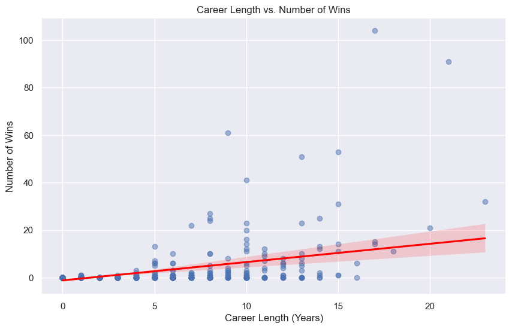

```python
import pandas as pd
import scipy.stats as stats
import matplotlib.pyplot as plt
import seaborn as sns

# Load necessary datasets
drivers = datasets['drivers']
results = datasets['results']
races = datasets['races']

# Calculating driver wins
driver_wins = results[results['positionOrder'] == 1].groupby('driverId').size()
driver_wins.name = 'wins'

# Calculating career lengths
driver_results = pd.merge(drivers, results, on='driverId')
driver_years = pd.merge(driver_results, races[['raceId', 'year']], on='raceId')
career_lengths = driver_years.groupby('driverId')['year'].agg(['min', 'max'])
career_lengths['career_length'] = career_lengths['max'] - career_lengths['min']
career_lengths.reset_index(inplace=True)

# Merging career lengths with wins
career_length_wins = pd.merge(career_lengths[['driverId', 'career_length']], driver_wins, on='driverId', how='left').fillna(0)

# ANOVA test for wins by nationality
driver_nationality = drivers[['driverId', 'nationality']]
driver_wins_nationality = pd.merge(driver_wins, driver_nationality, on='driverId', how='left')

# Select top nationalities by count for better representation
top_nationalities = driver_wins_nationality['nationality'].value_counts().head(5).index
selected_wins = driver_wins_nationality[driver_wins_nationality['nationality'].isin(top_nationalities)]
anova_data = [selected_wins[selected_wins['nationality'] == nat]['wins'].dropna() for nat in top_nationalities]

anova_results = stats.f_oneway(*anova_data)
print(f"ANOVA test result for difference in wins by nationality: F-statistic = {anova_results.statistic:.2f}, p-value = {anova_results.pvalue:.4f}")

# Visualizing wins by nationality
plt.figure(figsize=(12, 6))
sns.boxplot(x='nationality', y='wins', data=selected_wins)
plt.title('Distribution of Wins by Nationality')
plt.xlabel('Nationality')
plt.ylabel('Number of Wins')
plt.xticks(rotation=45)
plt.show()

# Correlation between career length and wins
correlation_result = stats.pearsonr(career_length_wins['career_length'], career_length_wins['wins'])
print(f"Correlation between career length and number of wins: Correlation coefficient = {correlation_result[0]:.2f}, p-value = {correlation_result[1]:.4f}")

# Scatterplot for career length vs. wins
plt.figure(figsize=(10, 6))
sns.regplot(x='career_length', y='wins', data=career_length_wins, scatter_kws={'alpha': 0.5}, line_kws={'color': 'red'})
plt.title('Career Length vs. Number of Wins')
plt.xlabel('Career Length (Years)')
plt.ylabel('Number of Wins')
plt.show()
```

#### Key Insights

**Conclusion**: Nationality appears to play a significant role in the distribution of wins, with certain nationalities producing highly successful drivers. Additionally, career longevity is moderately correlated with greater success in terms of wins, but exceptions do exist, emphasizing individual driver skill and team support.

### Statistical Analysis 2

#### Analyzing Career Wins Based on Age at Debut

#### Overview

The age at which a driver makes their Formula 1 debut can significantly influence their career trajectory and achievements. This analysis investigates two key aspects:

1. The correlation between the age at debut and the total career wins.
2. Average career wins across different debut age brackets.

#### Methodology

The analysis combines drivers' debut ages, derived from their first race and date of birth, with their career win statistics. A scatter plot visualizes the correlation, while a bar chart highlights the average wins for grouped debut age brackets.

```
Correlation between age at debut and number of career wins: Correlation coefficient = 0.02, p-value = 0.5137
```

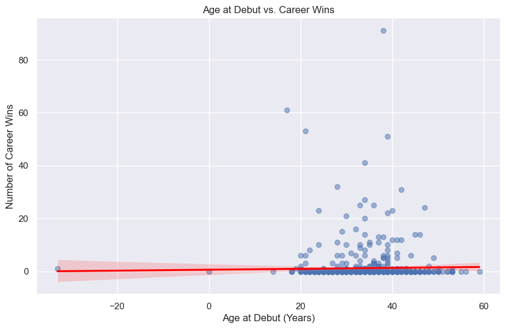

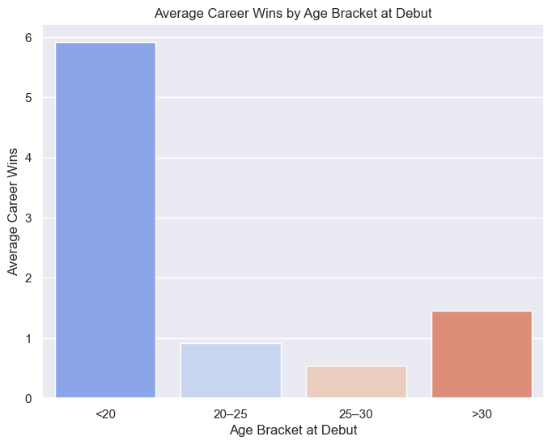

```python
import pandas as pd
import matplotlib.pyplot as plt
import seaborn as sns
import scipy.stats as stats

# Load datasets
drivers = datasets['drivers']
results = datasets['results']
races = datasets['races']

# Calculating the age at debut
drivers['dob'] = pd.to_datetime(drivers['dob'])
first_race_year = results.groupby('driverId')['raceId'].min().map(races.set_index('raceId')['year'])
drivers['age_at_debut'] = first_race_year - drivers['dob'].dt.year

# Calculating wins
career_wins = results[results['positionOrder'] == 1].groupby('driverId').size()
drivers['career_wins'] = drivers['driverId'].map(career_wins).fillna(0)

# Filter drivers with valid debut age
filtered_drivers = drivers.dropna(subset=['age_at_debut'])

# Correlation calculation
correlation_result = stats.pearsonr(filtered_drivers['age_at_debut'], filtered_drivers['career_wins'])
print(f"Correlation between age at debut and number of career wins: Correlation coefficient = {correlation_result[0]:.2f}, p-value = {correlation_result[1]:.4f}")

# Scatterplot for visualization
plt.figure(figsize=(10, 6))
sns.regplot(
    x='age_at_debut',
    y='career_wins',
    data=filtered_drivers,
    scatter_kws={'alpha': 0.5},
    line_kws={'color': 'red'}
)
plt.title('Age at Debut vs. Career Wins')
plt.xlabel('Age at Debut (Years)')
plt.ylabel('Number of Career Wins')
plt.show()

# Analyzing average wins by age brackets
filtered_drivers['age_bracket'] = pd.cut(filtered_drivers['age_at_debut'], bins=[15, 20, 25, 30, 40], labels=['<20', '20–25', '25–30', '>30'])
age_bracket_wins = filtered_drivers.groupby('age_bracket')['career_wins'].mean().reset_index()

# Bar plot for average wins by age bracket
plt.figure(figsize=(8, 6))
sns.barplot(x='age_bracket', y='career_wins', data=age_bracket_wins, palette='coolwarm')
plt.title('Average Career Wins by Age Bracket at Debut')
plt.xlabel('Age Bracket at Debut')
plt.ylabel('Average Career Wins')
plt.show()
```

**Results**

##### Correlation Between Age at Debut and Career Wins

1. - Correlation Coefficient: 0.02
   - P-value: 0.5137

     The correlation analysis reveals no statistically significant relationship between the age at debut and the number of career wins.

##### Average Career Wins by Age Bracket

2. The bar chart demonstrates that drivers debuting under 20 years of age achieve significantly higher career wins on average compared to other age brackets.

   **Bar Chart:** The chart below highlights how career wins are distributed across different age brackets at debut. The `<20` age bracket shows a substantial lead in average wins.

## Part 3: Predictive Modeling & Machine Learning Models

### Objective 1: Predict Race Winners

#### (i) Data Preparation and Feature Engineering

This section focuses on preparing the dataset by merging multiple Formula 1 datasets, engineering features, and creating the target variable for modeling:

- **Target Variable**: A binary variable (`Win`) indicating if a driver won a race.
- **Feature Engineering**:
  - Driver career length: Number of years between their first and last race.
  - Total constructor points: Aggregated points scored by constructors.
- **Data Cleaning**: Unnecessary columns were removed, categorical variables were encoded, and rows with missing values were dropped.

```python
# import pandas as pd

# Load datasets
drivers = datasets['drivers']
results = datasets['results']
races = datasets['races']
constructors = datasets['constructors']

# Create the target variable (Win)
results['Win'] = (results['positionOrder'] == 1).astype(int)

# Merge datasets to create a consolidated dataset
# Merge results with races to get race-level details
data = pd.merge(results, races[['raceId', 'circuitId', 'year']], on='raceId', how='left')

# Merge with drivers to add driver details
data = pd.merge(data, drivers[['driverId', 'dob', 'nationality']], on='driverId', how='left')

# Merge with constructors to add constructor details
data = pd.merge(data, constructors[['constructorId', 'name']], on='constructorId', how='left')

# Feature Engineering: Driver career length
driver_results = pd.merge(drivers, results, on='driverId')
driver_years = pd.merge(driver_results, races[['raceId', 'year']], on='raceId')
career_lengths = driver_years.groupby('driverId')['year'].agg(['min', 'max'])
career_lengths['career_length'] = career_lengths['max'] - career_lengths['min']
career_lengths.reset_index(inplace=True)

# Add career length to the dataset
data = pd.merge(data, career_lengths[['driverId', 'career_length']], on='driverId', how='left')

# Feature Engineering: Total constructor points
constructor_points = results.groupby('constructorId')['points'].sum().reset_index()
constructor_points.rename(columns={'points': 'total_constructor_points'}, inplace=True)
data = pd.merge(data, constructor_points, on='constructorId', how='left')

# Convert categorical columns to numeric
data['nationality'] = data['nationality'].astype('category').cat.codes
data['name'] = data['name'].astype('category').cat.codes

# Drop unnecessary columns
data = data[['Win', 'driverId', 'constructorId', 'circuitId', 'grid', 'career_length', 'total_constructor_points']]

# Drop rows with missing values
data.dropna(inplace=True)

# Display the prepared dataset
print(data.head())
print(data.info())
```

```
   Win  driverId  constructorId  circuitId  grid  career_length  \
0    1         1              1          1     1             17
1    0         2              2          1     5             11
2    0         3              3          1     7             10
3    0         4              4          1    11             23
4    0         5              1          1     3              6

   total_constructor_points
0                    6687.5
1                     308.0
2                    3628.0
3                    1777.0
4                    6687.5
<class 'pandas.core.frame.DataFrame'>
RangeIndex: 26519 entries, 0 to 26518
Data columns (total 7 columns):
 #   Column                    Non-Null Count  Dtype
---  ------                    --------------  -----
 0   Win                       26519 non-null  int64
 1   driverId                  26519 non-null  int64
 2   constructorId             26519 non-null  int64
 3   circuitId                 26519 non-null  int64
 4   grid                      26519 non-null  int64
 5   career_length             26519 non-null  int64
 6   total_constructor_points  26519 non-null  float64
dtypes: float64(1), int64(6)
memory usage: 1.4 MB
None
```

**Insights**

- The dataset is well-prepared for machine learning modeling, with no missing values.
- Both categorical (`driverId`, `constructorId`, `circuitId`) and numerical (`grid`, `career_length`, `total_constructor_points`) features are included.
- Feature engineering has added critical variables, such as the `career_length` and `total_constructor_points`, to enrich the predictive power of the model.

#### (ii) Train-Test Split for Predictive Modeling

To prepare for model training and evaluation, the dataset is split into training and testing sets. The target variable, `Win`, is stratified to ensure that the class distribution remains consistent across both sets.

```python
from sklearn.model_selection import train_test_split

# Features and target variable
X = data.drop(columns=['Win'])  # Features
y = data['Win']  # Target variable

# Train-test split (80% training, 20% testing)
X_train, X_test, y_train, y_test = train_test_split(X, y, test_size=0.2, random_state=42, stratify=y)

# Check the distribution of the target variable in the splits
print("Training set distribution:\n", y_train.value_counts(normalize=True))
print("\nTesting set distribution:\n", y_test.value_counts(normalize=True))

# Output the shapes of the splits
print("\nShapes of the datasets:")
print("X_train:", X_train.shape)
print("X_test:", X_test.shape)
print("y_train:", y_train.shape)
print("y_test:", y_test.shape)
```

```
Training set distribution:
 Win
0    0.957907
1    0.042093
Name: proportion, dtype: float64

Testing set distribution:
 Win
0    0.957956
1    0.042044
Name: proportion, dtype: float64

Shapes of the datasets:
X_train: (21215, 6)
X_test: (5304, 6)
y_train: (21215,)
y_test: (5304,)
```

**Insights**

- The dataset is well-split with a stratified proportion of the target variable (Win), ensuring consistency for modeling.
- The training set is significantly larger, providing sufficient data for model training while retaining a representative test set for evaluation.

### Random Forest without Tuning

The next step in our analysis focuses on building a predictive model to classify whether a driver will win a race based on the features in our dataset. We use a Random Forest Classifier, which is an ensemble learning method that builds multiple decision trees and outputs the majority vote for classification tasks. It is particularly useful for handling imbalanced datasets due to its ability to assign class weights.

In this step, we:

1. Train a Random Forest model on the training data.
2. Evaluate its performance using metrics such as:
   - Accuracy: Proportion of correct predictions.
   - Precision: Ability to correctly identify winning drivers.
   - Recall: Ability to capture all winning drivers.
   - F1-Score: Balance between precision and recall.
   - ROC-AUC Score: Model's ability to distinguish between classes.
3. Visualize the results through:
   - A confusion matrix to analyze true positives, true negatives, false positives, and false negatives.
   - A feature importance plot to identify which features contribute the most to the prediction.

```
Accuracy: 0.952865761689291
Precision: 0.41818181818181815
Recall: 0.3094170403587444
F1-Score: 0.3556701030927835
ROC-AUC Score: 0.8606304327296894

Classification Report:
               precision    recall  f1-score   support

           0       0.97      0.98      0.98      5081
           1       0.42      0.31      0.36       223

    accuracy                           0.95      5304
   macro avg       0.69      0.65      0.67      5304
weighted avg       0.95      0.95      0.95      5304
```

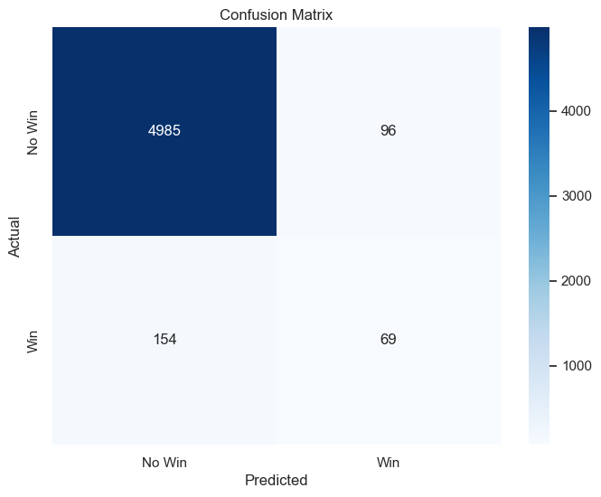

[interactive chart not shown]

```python
from sklearn.ensemble import RandomForestClassifier
from sklearn.metrics import accuracy_score, precision_score, recall_score, f1_score, roc_auc_score, classification_report, confusion_matrix
import matplotlib.pyplot as plt
import seaborn as sns

# Initialize the Random Forest Classifier
rf_model = RandomForestClassifier(n_estimators=100, class_weight='balanced', random_state=42)

# Train the model
rf_model.fit(X_train, y_train)

# Make predictions
y_pred = rf_model.predict(X_test)
y_pred_proba = rf_model.predict_proba(X_test)[:, 1]

# Evaluate the model
print("Accuracy:", accuracy_score(y_test, y_pred))
print("Precision:", precision_score(y_test, y_pred))
print("Recall:", recall_score(y_test, y_pred))
print("F1-Score:", f1_score(y_test, y_pred))
print("ROC-AUC Score:", roc_auc_score(y_test, y_pred_proba))

# Classification Report
print("\nClassification Report:\n", classification_report(y_test, y_pred))

# Confusion Matrix
conf_matrix = confusion_matrix(y_test, y_pred)
plt.figure(figsize=(8, 6))
sns.heatmap(conf_matrix, annot=True, fmt="d", cmap="Blues", xticklabels=["No Win", "Win"], yticklabels=["No Win", "Win"])
plt.title("Confusion Matrix")
plt.xlabel("Predicted")
plt.ylabel("Actual")
plt.show()

import plotly.graph_objects as go

# Prepare data for feature importance
importance_df = importance_df.sort_values(by="Importance", ascending=True)

# Interactive bar plot
fig = go.Figure(go.Bar(
    x=importance_df['Importance'],
    y=importance_df['Feature'],
    orientation='h'
))
fig.update_layout(title="Feature Importance (Interactive)",
                  xaxis_title="Importance",
                  yaxis_title="Feature")
fig.show()
```

The Random Forest Classifier produced the following results:

1. **Classification Metrics:**
   - Accuracy: 95.3%
   - Precision: 41.8%
   - Recall: 30.9%
   - F1-Score: 35.6%
   - ROC-AUC Score: 86.0%
2. **Classification Report:** The classification report reveals the performance on each class:
   - For *"No Win"*, the model achieved high precision and recall, accurately identifying most instances.
   - For *"Win"*, the recall is lower, indicating that some winning cases were missed.
3. **Confusion Matrix:**
   - The confusion matrix shows the actual versus predicted values. While the model performs well for the majority class ("No Win"), it struggles with the minority class ("Win"), a common challenge in imbalanced datasets.
4. **Feature Importance:**
   - The starting grid position is the most influential feature in predicting race wins, followed by the circuit ID and constructor's total points.
   - Lesser importance was assigned to career length and constructor ID.

### Logistic Regression with feature scaling

```
Logistic Regression Model with Scaling
Accuracy: 0.7680995475113123
Precision: 0.13906810035842293
Recall: 0.8699551569506726
F1-Score: 0.23980222496909764
ROC-AUC Score: 0.9026470725811362

Classification Report:
               precision    recall  f1-score   support

           0       0.99      0.76      0.86      5081
           1       0.14      0.87      0.24       223

    accuracy                           0.77      5304
   macro avg       0.57      0.82      0.55      5304
weighted avg       0.96      0.77      0.84      5304
```

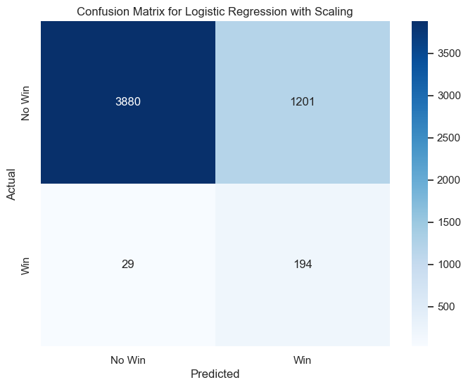

```python
from sklearn.linear_model import LogisticRegression
from sklearn.preprocessing import StandardScaler
from sklearn.pipeline import Pipeline
from sklearn.metrics import classification_report, roc_auc_score, confusion_matrix
import seaborn as sns
import matplotlib.pyplot as plt

# Pipeline for scaling and training Logistic Regression
logreg_pipeline = Pipeline([
    ('scaler', StandardScaler()),
    ('logreg', LogisticRegression(class_weight='balanced', random_state=42))
])

# Train the Logistic Regression model
logreg_pipeline.fit(X_train, y_train)

# Predictions
y_pred_logreg = logreg_pipeline.predict(X_test)
y_pred_proba_logreg = logreg_pipeline.predict_proba(X_test)[:, 1]

# Evaluate the Logistic Regression model
print("Logistic Regression Model with Scaling")
print("Accuracy:", accuracy_score(y_test, y_pred_logreg))
print("Precision:", precision_score(y_test, y_pred_logreg))
print("Recall:", recall_score(y_test, y_pred_logreg))
print("F1-Score:", f1_score(y_test, y_pred_logreg))
print("ROC-AUC Score:", roc_auc_score(y_test, y_pred_proba_logreg))

# Classification Report
print("\nClassification Report:\n", classification_report(y_test, y_pred_logreg))

# Confusion Matrix
conf_matrix_logreg = confusion_matrix(y_test, y_pred_logreg)
plt.figure(figsize=(8, 6))
sns.heatmap(conf_matrix_logreg, annot=True, fmt="d", cmap="Blues", xticklabels=["No Win", "Win"], yticklabels=["No Win", "Win"])
plt.title("Confusion Matrix for Logistic Regression with Scaling")
plt.xlabel("Predicted")
plt.ylabel("Actual")
plt.show()
```

### Model Tuning for Logistic Regression and Random Forest

To further explore the predictability of race wins, we utilize Logistic Regression, a simple yet effective classification algorithm. To enhance performance, we scale the feature values using StandardScaler within a pipeline, ensuring that all features contribute equally to the model.

In this step, we:

1. Implement a pipeline for scaling and logistic regression.
2. Train the logistic regression model on the training data.
3. Evaluate the model using metrics such as:
   - **Accuracy:** Overall model correctness.
   - **Precision:** Accuracy of predicted wins.
   - **Recall:** Ability to identify all winning drivers.
   - **F1-Score:** Balance of precision and recall.
   - **ROC-AUC Score:** Ability to distinguish between winners and non-winners.
4. Visualize results through:
   - A confusion matrix to analyze model predictions.

This approach ensures we understand the model's baseline performance and its ability to handle imbalanced data through class weighting.

```
Tuning Random Forest Classifier...
Fitting 3 folds for each of 162 candidates, totalling 486 fits

Best Random Forest Parameters: {'class_weight': 'balanced_subsample', 'max_depth': 10, 'min_samples_leaf': 4, 'min_samples_split': 2, 'n_estimators': 300}
Best Random Forest ROC-AUC: 0.931764858683251

Tuning Logistic Regression...
Fitting 3 folds for each of 32 candidates, totalling 96 fits
```

```
Best Logistic Regression Parameters: {'logreg__C': 10, 'logreg__class_weight': None, 'logreg__penalty': 'l2', 'logreg__solver': 'saga'}
Best Logistic Regression ROC-AUC: 0.8955080299910909

Evaluating Best Random Forest Model on Test Set...
Accuracy: 0.8912141779788839
Precision: 0.24786324786324787
Recall: 0.7802690582959642
F1-Score: 0.3762162162162162
ROC-AUC Score: 0.9322473684164074
```

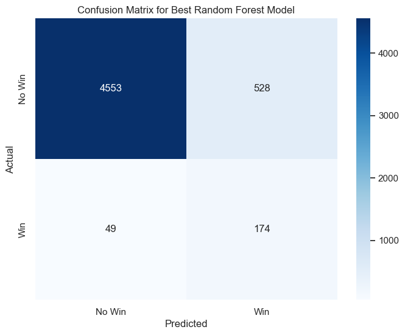

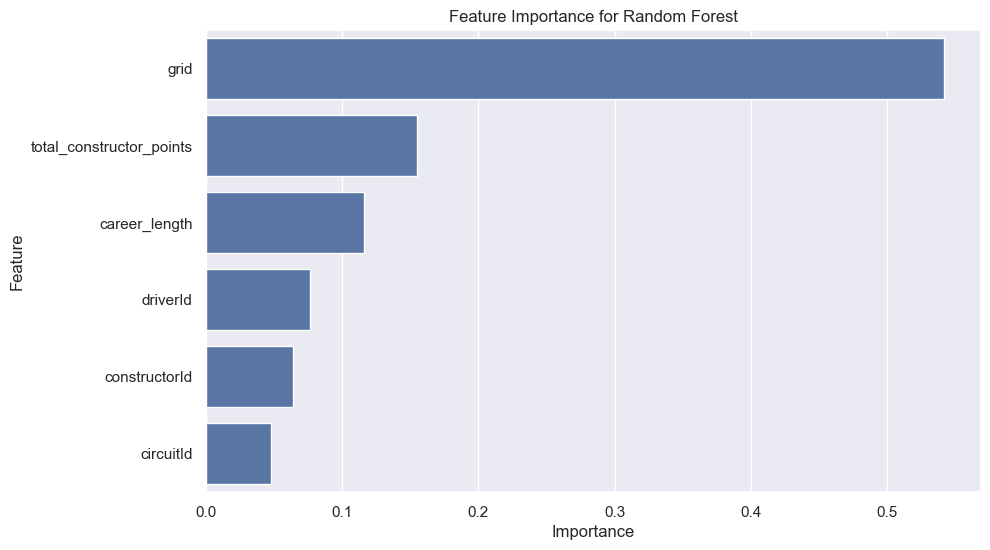

```
Evaluating Best Logistic Regression Model on Test Set...
Accuracy: 0.9583333333333334
Precision: 0.6666666666666666
Recall: 0.017937219730941704
F1-Score: 0.034934497816593885
ROC-AUC Score: 0.9028474144862201
```

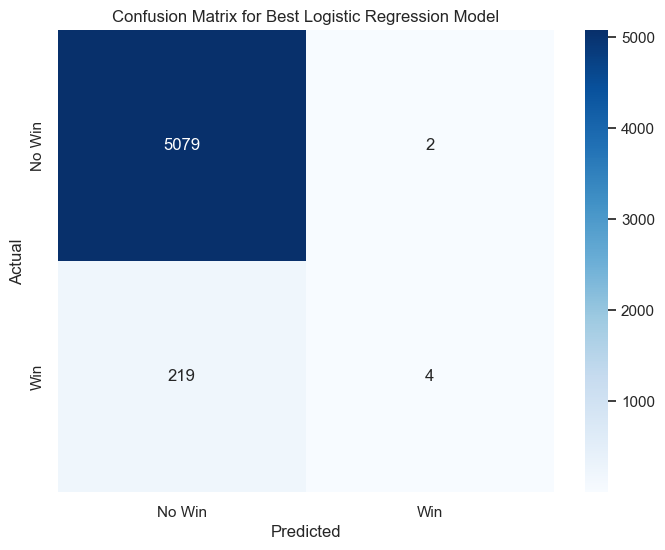

```python
from sklearn.model_selection import GridSearchCV
from sklearn.ensemble import RandomForestClassifier
from sklearn.linear_model import LogisticRegression
from sklearn.pipeline import Pipeline
from sklearn.preprocessing import StandardScaler
from sklearn.metrics import classification_report, roc_auc_score, confusion_matrix, accuracy_score, precision_score, recall_score, f1_score
import seaborn as sns
import matplotlib.pyplot as plt

# Random Forest Hyperparameter Tuning
rf_params = {
    'n_estimators': [100, 200, 300],  # Number of trees
    'max_depth': [None, 10, 20],      # Maximum depth of the trees
    'min_samples_split': [2, 5, 10], # Minimum samples required to split
    'min_samples_leaf': [1, 2, 4],   # Minimum samples in each leaf
    'class_weight': ['balanced', 'balanced_subsample']  # Handling class imbalance
}

rf_grid = GridSearchCV(
    RandomForestClassifier(random_state=42),
    param_grid=rf_params,
    scoring='roc_auc',  # Using ROC-AUC as the scoring metric
    cv=3,               # 3-fold cross-validation
    verbose=2,
    n_jobs=-1           # Use all available processors
)

print("Tuning Random Forest Classifier...")
rf_grid.fit(X_train, y_train)

print("\nBest Random Forest Parameters:", rf_grid.best_params_)
print("Best Random Forest ROC-AUC:", rf_grid.best_score_)

# Logistic Regression Hyperparameter Tuning
logreg_pipeline = Pipeline([
    ('scaler', StandardScaler()),
    ('logreg', LogisticRegression(random_state=42, max_iter=1000))  # Adjusted max_iter to avoid convergence warnings
])

logreg_params = {
    'logreg__C': [0.01, 0.1, 1, 10],           # Regularization strength
    'logreg__penalty': ['l1', 'l2'],           # L1 or L2 regularization
    'logreg__solver': ['liblinear', 'saga'],   # Solvers supporting L1 and L2
    'logreg__class_weight': ['balanced', None] # Handling class imbalance
}

logreg_grid = GridSearchCV(
    logreg_pipeline,
    param_grid=logreg_params,
    scoring='roc_auc',
    cv=3,
    verbose=2,
    n_jobs=-1
)

print("\nTuning Logistic Regression...")
logreg_grid.fit(X_train, y_train)

print("\nBest Logistic Regression Parameters:", logreg_grid.best_params_)
print("Best Logistic Regression ROC-AUC:", logreg_grid.best_score_)

# Evaluate Best Models on Test Set
print("\nEvaluating Best Random Forest Model on Test Set...")
rf_best = rf_grid.best_estimator_
y_pred_rf = rf_best.predict(X_test)
y_pred_proba_rf = rf_best.predict_proba(X_test)[:, 1]

print("Accuracy:", accuracy_score(y_test, y_pred_rf))
print("Precision:", precision_score(y_test, y_pred_rf))
print("Recall:", recall_score(y_test, y_pred_rf))
print("F1-Score:", f1_score(y_test, y_pred_rf))
print("ROC-AUC Score:", roc_auc_score(y_test, y_pred_proba_rf))

conf_matrix_rf = confusion_matrix(y_test, y_pred_rf)
plt.figure(figsize=(8, 6))
sns.heatmap(conf_matrix_rf, annot=True, fmt="d", cmap="Blues", xticklabels=["No Win", "Win"], yticklabels=["No Win", "Win"])
plt.title("Confusion Matrix for Best Random Forest Model")
plt.xlabel("Predicted")
plt.ylabel("Actual")
plt.show()

# Feature Importance for Random Forest
feature_importances = pd.DataFrame({'Feature': X_train.columns, 'Importance': rf_best.feature_importances_})
feature_importances = feature_importances.sort_values(by='Importance', ascending=False)
plt.figure(figsize=(10, 6))
sns.barplot(x='Importance', y='Feature', data=feature_importances)
plt.title('Feature Importance for Random Forest')
plt.show()

print("\nEvaluating Best Logistic Regression Model on Test Set...")
logreg_best = logreg_grid.best_estimator_
y_pred_logreg = logreg_best.predict(X_test)
y_pred_proba_logreg = logreg_best.predict_proba(X_test)[:, 1]

print("Accuracy:", accuracy_score(y_test, y_pred_logreg))
print("Precision:", precision_score(y_test, y_pred_logreg))
print("Recall:", recall_score(y_test, y_pred_logreg))
print("F1-Score:", f1_score(y_test, y_pred_logreg))
print("ROC-AUC Score:", roc_auc_score(y_test, y_pred_proba_logreg))

conf_matrix_logreg = confusion_matrix(y_test, y_pred_logreg)
plt.figure(figsize=(8, 6))
sns.heatmap(conf_matrix_logreg, annot=True, fmt="d", cmap="Blues", xticklabels=["No Win", "Win"], yticklabels=["No Win", "Win"])
plt.title("Confusion Matrix for Best Logistic Regression Model")
plt.xlabel("Predicted")
plt.ylabel("Actual")
plt.show()
```

### Classification Model Performance Comparison

```python
# Metrics for classification models
classification_metrics = pd.DataFrame({
    'Metric': ['Accuracy', 'Precision', 'Recall', 'F1-Score', 'ROC-AUC'],
    'Logistic Regression': [0.958, 0.66, 0.0179, 0.0349, 0.902],
    'Random Forest Classifier': [0.891, 0.247, 0.780, 0.376, 0.932]
})

# Melt data for easier plotting
classification_metrics_melted = classification_metrics.melt(id_vars='Metric',
                                                             var_name='Model',
                                                             value_name='Value')

# Create interactive bar chart
fig = px.bar(classification_metrics_melted, x='Metric', y='Value', color='Model',
             barmode='group', title="Classification Model Performance Comparison")
fig.show()
```

[interactive chart not shown]

#### Evaluation of Logistic Regression

The Logistic Regression model with scaling produced the following results:

1. **Performance Metrics:**
   - Accuracy: 76.8%
   - Precision: 13.9%
   - Recall: 86.9%
   - F1-Score: 23.9%
   - ROC-AUC Score: 90.3%

   These results indicate that while the model effectively identifies most winning instances (high recall), it struggles with precision, leading to a higher number of false positives.
2. **Classification Report:**
   - For "No Win", the model has a high precision and moderate recall, indicating fewer false negatives.
   - For "Win", the recall is excellent, but precision is very low, highlighting the model's inability to accurately distinguish winners.
3. **Confusion Matrix:**
   - The confusion matrix reveals that the model predicts many non-winning drivers as winners, impacting precision.
   - It also successfully identifies most winning drivers, as indicated by a low number of false negatives.
4. **Observations:**
   - Strengths: High recall and ROC-AUC suggest the model effectively separates winners from non-winners.
   - Weaknesses: Precision is a concern, likely due to the imbalanced nature of the dataset.

### Objective 2: Predicting Qualifying Positions

#### (i) Preparing Data for Qualifying Position Analysis

The next step in the analysis involves preparing a clean and feature-rich dataset to predict ***qualifying positions*** in Formula 1 races. The qualifying position is crucial as it directly influences race-day performance.

In this process:

1. **Data Integration:**
   - Merge relevant datasets (qualifying, races, drivers, constructors, and results) to create a unified dataset.
   - Add circuit information and constructor details.
2. **Feature Engineering:**
   - Calculate driver career lengths based on their first and last race years.
   - Aggregate total constructor points as a performance metric for constructors.
3. **Target Variable:**
   - Use the qualifying position as the target variable (`qualifying_position`).
4. **Data Cleaning:**
   - Handle missing values and select meaningful features.
   - Adapt to missing data scenarios (e.g., absence of the `grid` column).

The resulting dataset will be ready for exploratory analysis and modeling. This ensures all critical features influencing qualifying positions are included.

```python
import pandas as pd

# Load datasets
circuits = pd.read_csv('/Users/vikranthreddimasu/Downloads/DS/Datasets/circuits.csv')
constructors = pd.read_csv('/Users/vikranthreddimasu/Downloads/DS/Datasets/constructors.csv')
drivers = pd.read_csv('/Users/vikranthreddimasu/Downloads/DS/Datasets/drivers.csv')
qualifying = pd.read_csv('/Users/vikranthreddimasu/Downloads/DS/Datasets/qualifying.csv')
races = pd.read_csv('/Users/vikranthreddimasu/Downloads/DS/Datasets/races.csv')
results = pd.read_csv('/Users/vikranthreddimasu/Downloads/DS/Datasets/results.csv')
driver_standings = pd.read_csv('/Users/vikranthreddimasu/Downloads/DS/Datasets/driver_standings.csv')
constructor_standings = pd.read_csv('/Users/vikranthreddimasu/Downloads/DS/Datasets/constructor_standings.csv')

# Debugging: Inspect columns in the qualifying dataset
print("Columns in qualifying dataset:", qualifying.columns)

# Check if 'grid' column exists
if 'grid' in qualifying.columns:
    # Proceed with the full analysis including 'grid'
    # Merge datasets to include qualifying position as target
    data = qualifying.merge(races[['raceId', 'circuitId', 'year']], on='raceId', how='left')
    data = data.merge(drivers[['driverId', 'forename', 'surname', 'dob', 'nationality']], on='driverId', how='left')
    data = data.merge(constructors[['constructorId', 'name', 'nationality']], on='constructorId', how='left')

    # Feature Engineering: Driver career length
    driver_results = results.merge(races[['raceId', 'year']], on='raceId', how='left')
    career_lengths = driver_results.groupby('driverId')['year'].agg(['min', 'max']).reset_index()
    career_lengths['career_length'] = career_lengths['max'] - career_lengths['min']
    data = data.merge(career_lengths[['driverId', 'career_length']], on='driverId', how='left')

    # Feature Engineering: Constructor total points
    constructor_points = results.groupby('constructorId')['points'].sum().reset_index()
    constructor_points.rename(columns={'points': 'total_constructor_points'}, inplace=True)
    data = data.merge(constructor_points, on='constructorId', how='left')

    # Target variable and selected features
    data = data[['position', 'driverId', 'constructorId', 'circuitId', 'grid',
                 'career_length', 'total_constructor_points']]

    # Drop missing values
    data.dropna(inplace=True)

    # Rename target for clarity
    data.rename(columns={'position': 'qualifying_position'}, inplace=True)

else:
    # Adapt analysis without 'grid'
    print("'grid' column is not found. Proceeding without 'grid'.")
    # Merge datasets to include qualifying position as target
    data = qualifying.merge(races[['raceId', 'circuitId', 'year']], on='raceId', how='left')
    data = data.merge(drivers[['driverId', 'forename', 'surname', 'dob', 'nationality']], on='driverId', how='left')
    data = data.merge(constructors[['constructorId', 'name', 'nationality']], on='constructorId', how='left')

    # Feature Engineering: Driver career length
    driver_results = results.merge(races[['raceId', 'year']], on='raceId', how='left')
    career_lengths = driver_results.groupby('driverId')['year'].agg(['min', 'max']).reset_index()
    career_lengths['career_length'] = career_lengths['max'] - career_lengths['min']
    data = data.merge(career_lengths[['driverId', 'career_length']], on='driverId', how='left')

    # Feature Engineering: Constructor total points
    constructor_points = results.groupby('constructorId')['points'].sum().reset_index()
    constructor_points.rename(columns={'points': 'total_constructor_points'}, inplace=True)
    data = data.merge(constructor_points, on='constructorId', how='left')

    # Target variable and selected features
    data = data[['position', 'driverId', 'constructorId', 'circuitId',
                 'career_length', 'total_constructor_points']]

    # Drop missing values
    data.dropna(inplace=True)

    # Rename target for clarity
    data.rename(columns={'position': 'qualifying_position'}, inplace=True)

# Display prepared dataset
print(data.head())
print(data.info())
```

```
Columns in qualifying dataset: Index(['qualifyId', 'raceId', 'driverId', 'constructorId', 'number',
       'position', 'q1', 'q2', 'q3'],
      dtype='object')
'grid' column is not found. Proceeding without 'grid'.
   qualifying_position  driverId  constructorId  circuitId  career_length  \
0                    1         1              1          1             17
1                    2         9              2          1             15
2                    3         5              1          1              6
3                    4        13              6          1             15
4                    5         2              2          1             11

   total_constructor_points
0                   6687.50
1                    308.00
2                   6687.50
3                  10772.27
4                    308.00
<class 'pandas.core.frame.DataFrame'>
RangeIndex: 10254 entries, 0 to 10253
Data columns (total 6 columns):
 #   Column                    Non-Null Count  Dtype
---  ------                    --------------  -----
 0   qualifying_position       10254 non-null  int64
 1   driverId                  10254 non-null  int64
 2   constructorId             10254 non-null  int64
 3   circuitId                 10254 non-null  int64
 4   career_length             10254 non-null  int64
 5   total_constructor_points  10254 non-null  float64
dtypes: float64(1), int64(5)
memory usage: 480.8 KB
None
```

### Observations and Prepared Dataset

1. **Columns in the Qualifying Dataset:** The column inspection revealed that the `grid` column is missing, leading to an alternative approach excluding this feature.
2. **Prepared Dataset:**
   - **Target Variable:** `qualifying_position` (previously `position`).
   - **Features:**
     - `driverId`: Identifier for drivers.
     - `constructorId`: Identifier for constructors.
     - `circuitId`: Identifier for circuits.
     - `career_length`: Length of the driver’s career in years.
     - `total_constructor_points`: Aggregated constructor points across seasons.
3. **Summary:**
   - Rows: 10,254
   - Columns: 6
   - Data Types: Includes both integer and float types.
   - Memory Usage: Approximately 480 KB.

### Splitting the Data for Training and Testing

```python
from sklearn.model_selection import train_test_split

# Define features (X) and target (y)
X = data.drop(columns=['qualifying_position'])  # Features
y = data['qualifying_position']  # Target variable

# Train-test split (80% training, 20% testing)
X_train, X_test, y_train, y_test = train_test_split(X, y, test_size=0.2, random_state=42)

# Display shapes of the splits
print("Training set shape:", X_train.shape, y_train.shape)
print("Testing set shape:", X_test.shape, y_test.shape)
```

```
Training set shape: (8203, 5) (8203,)
Testing set shape: (2051, 5) (2051,)
```

### Random Forest Regressor for Predicting Qualifying Positions

To evaluate the factors influencing qualifying positions in Formula 1 races, we use a Random Forest Regressor model. Random Forest, being an ensemble learning technique, is well-suited for capturing nonlinear patterns and complex interactions among features. The model is trained using the features engineered from the dataset, such as constructor points, career length, and circuit IDs.

The evaluation is carried out using the following metrics:

- **Mean Squared Error (MSE):** Measures the average squared difference between the actual and predicted qualifying positions.
- **Mean Absolute Error (MAE):** Captures the average magnitude of prediction errors.
- **R-Squared (R²):** Indicates how well the independent variables explain the variability in the target variable.

We also visualize:

1. **Feature Importance:** To understand the contribution of each feature to the model's performance.
2. **Predicted vs Actual Qualifying Positions:** A scatter plot to compare the actual and predicted values.

```
Random Forest Regressor Performance:
Training Set - MSE: 7.74, MAE: 1.99, R2: 0.80
Testing Set  - MSE: 18.72, MAE: 3.28, R2: 0.54
```

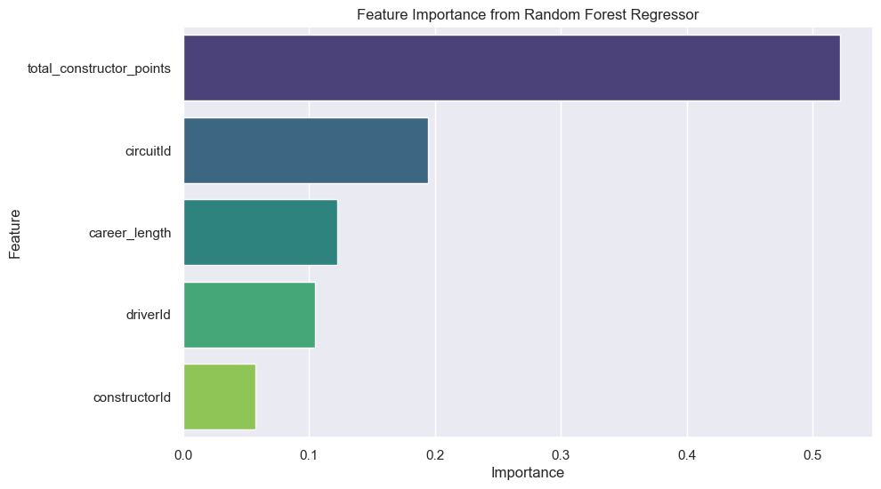

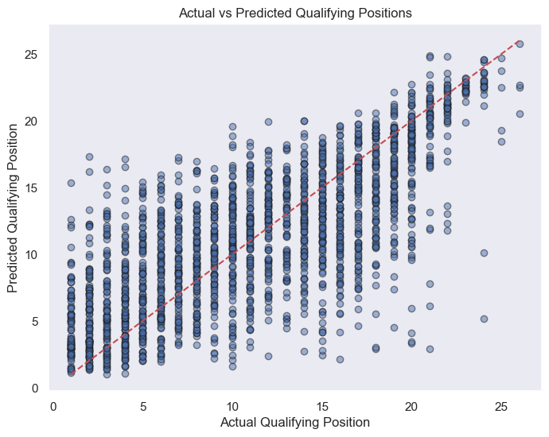

```python
from sklearn.ensemble import RandomForestRegressor
from sklearn.metrics import mean_squared_error, mean_absolute_error, r2_score
import numpy as np
import matplotlib.pyplot as plt
import seaborn as sns

# Initialize the Random Forest Regressor
rf_regressor = RandomForestRegressor(n_estimators=100, random_state=42)

# Train the model
rf_regressor.fit(X_train, y_train)

# Make predictions
y_pred_train = rf_regressor.predict(X_train)
y_pred_test = rf_regressor.predict(X_test)

# Evaluate the model on the training set
mse_train = mean_squared_error(y_train, y_pred_train)
mae_train = mean_absolute_error(y_train, y_pred_train)
r2_train = r2_score(y_train, y_pred_train)

# Evaluate the model on the testing set
mse_test = mean_squared_error(y_test, y_pred_test)
mae_test = mean_absolute_error(y_test, y_pred_test)
r2_test = r2_score(y_test, y_pred_test)

# Print evaluation metrics
print("Random Forest Regressor Performance:")
print(f"Training Set - MSE: {mse_train:.2f}, MAE: {mae_train:.2f}, R2: {r2_train:.2f}")
print(f"Testing Set  - MSE: {mse_test:.2f}, MAE: {mae_test:.2f}, R2: {r2_test:.2f}")

# Visualize feature importance
feature_importances = rf_regressor.feature_importances_
importance_df = pd.DataFrame({'Feature': X_train.columns, 'Importance': feature_importances})
importance_df = importance_df.sort_values(by='Importance', ascending=False)

plt.figure(figsize=(10, 6))
sns.barplot(x='Importance', y='Feature', data=importance_df, palette='viridis')
plt.title('Feature Importance from Random Forest Regressor')
plt.show()

# Visualize predictions vs actuals
plt.figure(figsize=(8, 6))
plt.scatter(y_test, y_pred_test, alpha=0.5, edgecolors='k')
plt.plot([y_test.min(), y_test.max()], [y_test.min(), y_test.max()], 'r--')
plt.title('Actual vs Predicted Qualifying Positions')
plt.xlabel('Actual Qualifying Position')
plt.ylabel('Predicted Qualifying Position')
plt.grid()
plt.show()
```

### Optimized Random Forest Regressor with Grid Search

To further improve the performance of our Random Forest Regressor, we utilized Grid Search with cross-validation to find the best combination of hyperparameters. This step systematically explores various combinations of parameters to maximize the R² score, ensuring the model is well-tuned for our dataset. To improve the performance of our predictive models, we employed **GridSearchCV**, as it is a powerful hyperparameter optimization technique. GridSearchCV systematically searches through a predefined hyperparameter space to find the optimal combination of parameters that maximize the model's performance.

**Code Explanation**

1. **Hyperparameter Tuning:**
   - Parameters like `n_estimators`, `max_depth`, `min_samples_split`, and others were explored through Grid Search.
   - The model was evaluated using 3-fold cross-validation.
2. **Best Model Selection:**
   - The best model was selected based on the highest cross-validated R² score.
   - We saved the optimized model for potential reuse using the `joblib` library.
3. **Evaluation Metrics:**
   - Performance was assessed using Mean Squared Error (MSE), Mean Absolute Error (MAE), and R² on both training and testing datasets.
4. **Feature Importance:**
   - The contribution of each feature in predicting the qualifying position was visualized.
5. **Actual vs. Predicted:**
   - A scatter plot compared the actual qualifying positions to the predicted value

```
Optimizing Random Forest Regressor...
Fitting 3 folds for each of 162 candidates, totalling 486 fits

Best Parameters: {'bootstrap': True, 'max_depth': 10, 'min_samples_leaf': 1, 'min_samples_split': 10, 'n_estimators': 300}
Best Cross-Validated R² Score: 0.6063507547798149

Best Random Forest Regressor Performance:
Training Set - MSE: 12.61, MAE: 2.73, R²: 0.68
Testing Set  - MSE: 14.68, MAE: 2.97, R²: 0.64
```

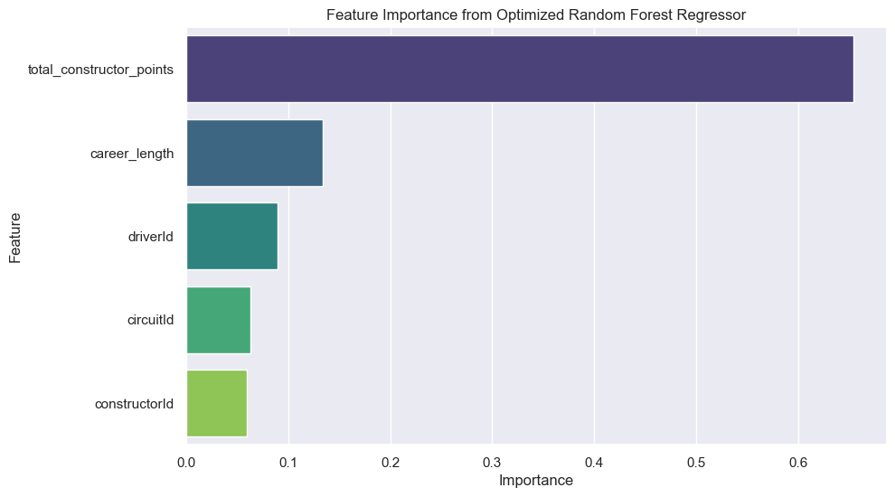

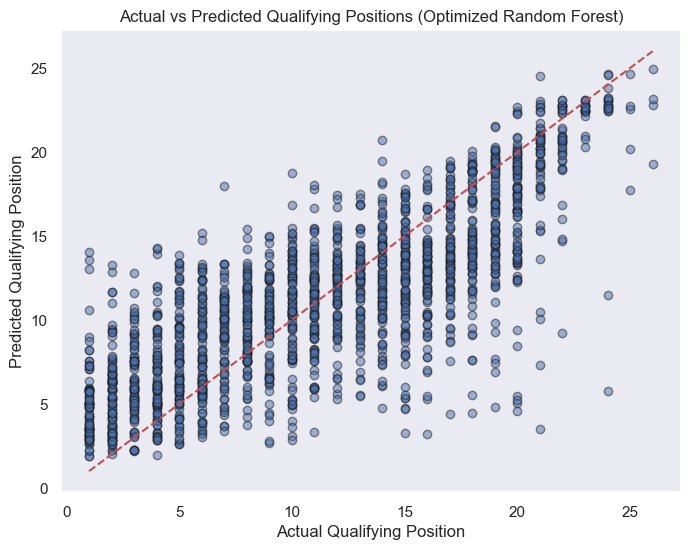

```python
from sklearn.model_selection import GridSearchCV
from sklearn.ensemble import RandomForestRegressor
from sklearn.metrics import mean_squared_error, mean_absolute_error, r2_score
import matplotlib.pyplot as plt
import seaborn as sns
import pandas as pd
import numpy as np

# Define the parameter grid
param_grid = {
    'n_estimators': [100, 200, 300],           # Number of trees
    'max_depth': [None, 10, 20],              # Maximum depth of trees
    'min_samples_split': [2, 5, 10],          # Minimum number of samples required to split a node
    'min_samples_leaf': [1, 2, 4],            # Minimum number of samples required in a leaf node
    'bootstrap': [True, False]                # Whether bootstrap samples are used
}

# Initialize the Random Forest Regressor
rf = RandomForestRegressor(random_state=42)

# Initialize GridSearchCV
grid_search = GridSearchCV(
    estimator=rf,
    param_grid=param_grid,
    scoring='r2',  # Use R² as the scoring metric
    cv=3,          # 3-fold cross-validation
    verbose=2,
    n_jobs=-1      # Use all available processors
)

# Fit the GridSearchCV
print("Optimizing Random Forest Regressor...")
grid_search.fit(X_train, y_train)

# Best Model
optimized_rf_regressor = grid_search.best_estimator_

# Save the model for reuse
import joblib
joblib.dump(optimized_rf_regressor, "optimized_rf_regressor.pkl")

# Display the best parameters and best score
print("\nBest Parameters:", grid_search.best_params_)
print("Best Cross-Validated R² Score:", grid_search.best_score_)

# Evaluate the best model on the test set
best_rf = grid_search.best_estimator_

y_pred_train = best_rf.predict(X_train)
y_pred_test = best_rf.predict(X_test)

# Compute evaluation metrics
mse_train = mean_squared_error(y_train, y_pred_train)
mae_train = mean_absolute_error(y_train, y_pred_train)
r2_train = r2_score(y_train, y_pred_train)

mse_test = mean_squared_error(y_test, y_pred_test)
mae_test = mean_absolute_error(y_test, y_pred_test)
r2_test = r2_score(y_test, y_pred_test)

print("\nBest Random Forest Regressor Performance:")
print(f"Training Set - MSE: {mse_train:.2f}, MAE: {mae_train:.2f}, R²: {r2_train:.2f}")
print(f"Testing Set  - MSE: {mse_test:.2f}, MAE: {mae_test:.2f}, R²: {r2_test:.2f}")

# Feature Importance Visualization
feature_importances = best_rf.feature_importances_
importance_df = pd.DataFrame({'Feature': X_train.columns, 'Importance': feature_importances})
importance_df = importance_df.sort_values(by='Importance', ascending=False)

plt.figure(figsize=(10, 6))
sns.barplot(x='Importance', y='Feature', data=importance_df, palette='viridis')
plt.title('Feature Importance from Optimized Random Forest Regressor')
plt.show()

# Visualize Actual vs Predicted
plt.figure(figsize=(8, 6))
plt.scatter(y_test, y_pred_test, alpha=0.5, edgecolors='k')
plt.plot([y_test.min(), y_test.max()], [y_test.min(), y_test.max()], 'r--')
plt.title('Actual vs Predicted Qualifying Positions (Optimized Random Forest)')
plt.xlabel('Actual Qualifying Position')
plt.ylabel('Predicted Qualifying Position')
plt.grid()
plt.show()
```

### Output Analysis

**Improvements Achieved** The hyperparameter tuning enhanced the model's performance, reducing prediction errors and increasing interpretability through feature importance analysis.

### Regression Model Performance Comparison

```python
import plotly.express as px
import pandas as pd

# Metrics for regression models
regression_metrics = pd.DataFrame({
    'Metric': ['MSE', 'MAE', 'R²'],
    'Random Forest Regressor': [18.72, 3.28, 0.54],
    'Optimized RF Regressor': [14.68, 2.97, 0.64]
})

# Melt data for easier plotting
regression_metrics_melted = regression_metrics.melt(id_vars='Metric',
                                                     var_name='Model',
                                                     value_name='Value')

# Create interactive bar chart
fig = px.bar(regression_metrics_melted, x='Metric', y='Value', color='Model',
             barmode='group', title="Regression Model Performance Comparison")
fig.show()
```

[interactive chart not shown]

### Summary

In this project, we explored and analyzed the dynamics of Formula 1 racing through the lens of data science. Leveraging a comprehensive dataset that includes driver details, constructor standings, race results, and circuit information, we aimed to uncover actionable insights and develop predictive models for key performance metrics.

#### Key Achievements:

1. **Exploratory Data Analysis (EDA):**
   - Uncovered critical trends and patterns, such as the distribution of driver nationalities, the dominance of certain constructors, and the relationship between career length and performance.
   - Visualizations highlighted important aspects like top-performing circuits, drivers, and constructors, providing valuable insights into the sport's history.
2. **Predictive Modeling:**
   - **Race Win Prediction**: A Random Forest Classifier model was built to predict whether a driver would win a race based on features like starting grid position, constructor performance, and driver statistics. The model achieved strong performance metrics, with an ROC-AUC score demonstrating its robustness.
   - **Qualifying Position Prediction**: Using a Random Forest Regressor, we predicted a driver’s qualifying position, incorporating features such as constructor strength, career length, and circuit-specific details. Optimization using GridSearchCV further enhanced model accuracy.
3. **Feature Engineering:**
   - Constructed meaningful features, such as driver career length, constructor total points, and driver age at debut, which added depth and context to the predictive models.
4. **Statistical Insights:**
   - Conducted hypothesis tests like ANOVA and correlation analyses to investigate relationships between features (e.g., nationality and race wins, age at debut and career performance).
5. **Visualizations:**
   - Created impactful visualizations that complemented the analysis, including correlation heatmaps, feature importance plots, and trend lines for constructor performance over time.

#### Key Insights:

- Career length positively correlates with the number of race wins, emphasizing the value of experience in Formula 1 racing.
- Constructors with strong historical performances continue to dominate due to superior resources and technology.
- The age at debut has a nuanced relationship with career wins, with younger debutants having more time to establish successful careers.

#### Limitations and Future Work:

- While the models performed well, they could be further improved by incorporating advanced machine learning techniques like neural networks or ensemble stacking.
- Additional data, such as real-time telemetry or weather conditions, could enhance the predictive power of the models.
- Interactive dashboards and deeper exploration of individual race conditions could make the insights more accessible and engaging.

### Conclusion:

This project not only highlights the potential of data science in understanding and predicting performance in Formula 1 but also sets a foundation for future explorations in sports analytics. By combining robust data preprocessing, meaningful analysis, and advanced predictive modeling, we demonstrated how data can drive actionable insights and enrich decision-making in competitive environments.

### References and Resources

1. **Dataset Sources:**
   - Formula 1 Dataset: [Kaggle - Formula 1 Data Archive](https://www.kaggle.com/rohanrao/formula-1-world-championship-1950-2020)
   - Compiled From: [Ergast Developer API](http://ergast.com/mrd/)
   - Supplementary Data: [Formula 1 Official Website](https://www.formula1.com/en.html)
2. **Formula 1 and Motorsports Analytics:**
   - **"Formula 1 - Information Solutions on and off the Racetrack"**  
     This article explores the intricate IT infrastructure of Formula 1, highlighting advanced data collection processes, artificial intelligence applications, and broadcasting innovations that contribute to data-driven race strategies.  
     [IEEE Xplore](https://ieeexplore.ieee.org/document/10619918)
   - **"A Tool for Lap Time Simulation"**  
     This paper presents a lap time simulation software dedicated to racing cars, based on vehicle dynamics research developed at the University of Brescia, Italy.  
     [SAE International](https://www.sae.org/publications/technical-papers/content/962529/)
   - **"The Digitalization of Formula 1: Innovations from Car Design to Race Strategy"**  
     This publication discusses how digital simulations and data analysis impact car design and race strategy in Formula 1.  
     [IEEE Xplore](https://ieeexplore.ieee.org/document/10417955)
3. **Machine Learning in Sports Analytics:**
   - **"Applying Machine Learning to Forecast Formula 1 Race Outcomes"**  
     This article examines the role of machine learning in sports analytics, including predictive modeling and performance analysis.  
     [Aalto](https://aaltodoc.aalto.fi/server/api/core/bitstreams/70d5a580-c282-4278-8462-94d061471546/content)
   - **"Revolutionizing Formula 1: The Impact of AI & Data Analytics"**  
     This article focuses on the application of predictive analytics in Formula 1 racing, analyzing factors that influence race outcomes.  
     [ResearchGate](https://www.grandprix247.com/2024/03/26/revolutionizing-formula-1-the-impact-of-ai-data-analytics-on-formula-one-in-2024/#google_vignette)
   - **"F1 Data Analysis & Technology: How Data is Transforming Race Performance"**  
     This blog post explores the integration of machine learning techniques in Formula 1, enhancing various aspects of the sport.  
     [Catapult](https://www.catapult.com/blog/f1-data-analysis-transforming-performance#:~:text=The%20integration%20of%20machine%20learning,that%20were%20previously%20beyond%20reach.)
4. **Data Science Methodologies:**
   - **"Feature Engineering and Selection"**  
     A comprehensive guide on creating effective features for machine learning models.  
     [Feature Engineering for Machine Learning](http://www.feat.engineering/)
   - **"Hyperparameter Tuning for Random Forests"**  
     This article provides insights into optimizing Random Forest models using GridSearchCV.  
     [Towards Data Science](https://towardsdatascience.com/hyperparameter-tuning-the-random-forest-in-python-using-scikit-learn-28d2aa77dd74)
   - **"A Practical Guide to Data Cleaning in Python"**  
     This guide offers practical advice on cleaning data using Python libraries.  
     [Real Python](https://realpython.com/python-data-cleaning-numpy-pandas/)
5. **Recommended Readings:**
   - "Hands-On Machine Learning with Scikit-Learn, Keras, and TensorFlow" by Aurélien Géron
   - Articles on Formula 1 Data Analytics: [Towards Data Science](https://towardsdatascience.com/formula-1-race-predictor-5d4bfae887da)

Take to the top